# practical_exercise_2, Methods 3, 2021, autumn semester

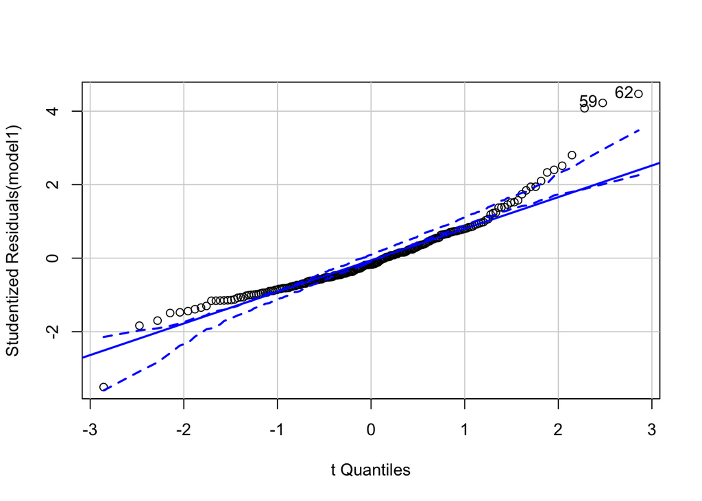

```
## 59 62
## 56 59
```

```r
qqPlot(model1)
```

```
iv. Also make a quantile-quantile plot for the residuals of the  multilevel model with two intercepts. Does it look alright?
```

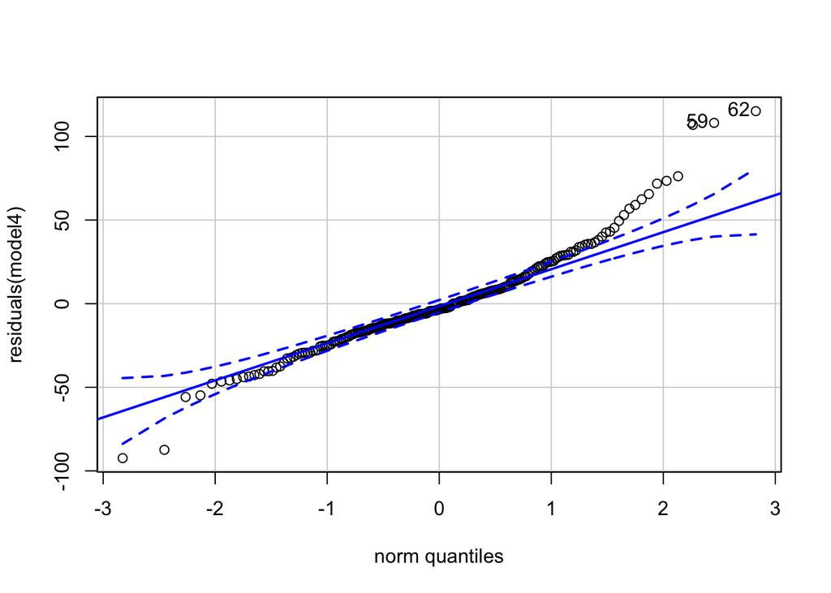

```
## 62 59
## 59 56
```

```r
qqPlot(residuals(model4))
```

Not really sure… To the right it looks a bit weird.

3. Plotting the two-intercepts model
   1. Create a plot for each subject, (similar to part 3 in Exercise 1), this time also indicating the fitted value for each of the subjects for each for the scenarios (hint use `fixef` to get the “grand effects” for each gender and `ranef` to get the subject- and scenario-specific effects)

```r
grand_effects <- fixef(model4)
specific_effects <- ranef(model4)
grand_effects
```

```
## (Intercept)     genderM
##    246.7650   -115.1746
```

```r
specific_effects
```

```
## $subject
##    (Intercept)
## F1  -10.490356
## F2   10.251809
## F3    3.795129
## F4  -29.495270
## F5   47.093999
## F6  -18.396273
## F7   -6.976691
## F8   -8.521934
## F9   12.739587
## M1   21.052117
## M2   -5.462358
## M3   33.561535
## M4   16.093337
## M5  -28.267430
## M6  -12.640202
## M7  -24.336998
##
## $scenario
##   (Intercept)
## 1  -11.595496
## 2    5.321218
## 3    6.795658
## 4   11.348815
## 5    1.411037
## 6   -8.622136
## 7   -4.659096
##
## with conditional variances for "subject" "scenario"
```

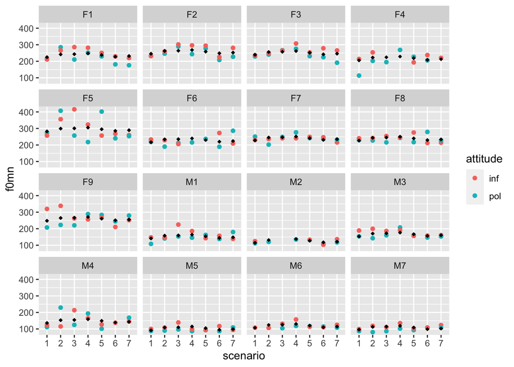

```r
ggplot(data = politeness, aes(x = scenario, y = f0mn, color = attitude)) +
  geom_point() +
  geom_point(aes(x = scenario, y = fitted(model4)), color = "black", shape = 18)+
  facet_wrap(~subject)
```

I’m a bit confused, since we don’t include attitude in any of the models, so the fitted values will not take this into acconut.

## Exercise 3 - now with attitude

1. Carry on with the model with the two unique intercepts fitted (*scenario* and *subject*).
   1. now build a model that has *attitude* as a main effect besides *gender*

```r
model5 <- lmerTest::lmer(f0mn~gender + attitude + (1|scenario) + (1|subject), politeness)
summary(model5)
```

```
## Linear mixed model fit by REML. t-tests use Satterthwaite's method [
## lmerModLmerTest]
## Formula: f0mn ~ gender + attitude + (1 | scenario) + (1 | subject)
##    Data: politeness
##
## REML criterion at convergence: 2065.1
##
## Scaled residuals:
##     Min      1Q  Median      3Q     Max
## -2.8511 -0.6081 -0.0602  0.4329  3.8745
##
## Random effects:
##  Groups   Name        Variance Std.Dev.
##  subject  (Intercept) 585.6    24.20
##  scenario (Intercept) 106.7    10.33
##  Residual             882.7    29.71
## Number of obs: 212, groups:  subject, 16; scenario, 7
##
## Fixed effects:
##             Estimate Std. Error       df t value Pr(>|t|)
## (Intercept)  254.398      9.597   19.480  26.507  < 2e-16 ***
## genderM     -115.437     12.881   14.066  -8.962 3.44e-07 ***
## attitudepol  -14.819      4.096  189.652  -3.618 0.000381 ***
## ---
## Signif. codes:  0 '***' 0.001 '**' 0.01 '*' 0.05 '.' 0.1 ' ' 1
##
## Correlation of Fixed Effects:
##             (Intr) gendrM
## genderM     -0.587
## attitudepol -0.220  0.006
```

```
ii. make a separate model that besides the main effects of _attitude_ and _gender_ also include their interaction
```

```r
model6 <- lmerTest::lmer(f0mn~gender*attitude + (1|scenario) + (1|subject), politeness)
summary(model6)
```

```
## Linear mixed model fit by REML. t-tests use Satterthwaite's method [
## lmerModLmerTest]
## Formula: f0mn ~ gender * attitude + (1 | scenario) + (1 | subject)
##    Data: politeness
##
## REML criterion at convergence: 2058.6
##
## Scaled residuals:
##     Min      1Q  Median      3Q     Max
## -2.8120 -0.5884 -0.0645  0.4014  3.9100
##
## Random effects:
##  Groups   Name        Variance Std.Dev.
##  subject  (Intercept) 584.4    24.17
##  scenario (Intercept) 106.4    10.32
##  Residual             885.5    29.76
## Number of obs: 212, groups:  subject, 16; scenario, 7
##
## Fixed effects:
##                     Estimate Std. Error       df t value Pr(>|t|)
## (Intercept)          255.618      9.761   20.909  26.186  < 2e-16 ***
## genderM             -118.232     13.531   17.158  -8.738    1e-07 ***
## attitudepol          -17.192      5.423  188.445  -3.170  0.00178 **
## genderM:attitudepol    5.544      8.284  188.491   0.669  0.50412
## ---
## Signif. codes:  0 '***' 0.001 '**' 0.01 '*' 0.05 '.' 0.1 ' ' 1
##
## Correlation of Fixed Effects:
##             (Intr) gendrM atttdp
## genderM     -0.606
## attitudepol -0.286  0.206
## gndrM:tttdp  0.187 -0.309 -0.654
```

```
iii. describe what the interaction term in the model says about Korean men's pitch when they are polite relative to Korean women's pitch when they are polite (you don't have to judge whether it is interesting)
```

Don’t quite know how to interpret the interaction… But it seems that men lower their pitch less in formal situations than women?

2. Compare the three models (1. gender as a main effect; 2. gender and attitude as main effects; 3. gender and attitude as main effects and the interaction between them. For all three models model unique intercepts for *subject* and *scenario*) using residual variance, residual standard deviation and AIC.

```r
#Residual variance
summary(model4) #939.91
```

```
## Linear mixed model fit by REML. t-tests use Satterthwaite's method [
## lmerModLmerTest]
## Formula: f0mn ~ gender + (1 | scenario) + (1 | subject)
##    Data: politeness
##
## REML criterion at convergence: 2082.5
##
## Scaled residuals:
##     Min      1Q  Median      3Q     Max
## -3.0131 -0.5373 -0.1089  0.4381  3.7558
##
## Random effects:
##  Groups   Name        Variance Std.Dev.
##  subject  (Intercept) 588.83   24.266
##  scenario (Intercept)  96.17    9.807
##  Residual             939.92   30.658
## Number of obs: 212, groups:  subject, 16; scenario, 7
##
## Fixed effects:
##             Estimate Std. Error       df t value Pr(>|t|)
## (Intercept)  246.765      9.327   17.347   26.46 1.82e-15 ***
## genderM     -115.175     12.955   14.064   -8.89 3.79e-07 ***
## ---
## Signif. codes:  0 '***' 0.001 '**' 0.01 '*' 0.05 '.' 0.1 ' ' 1
##
## Correlation of Fixed Effects:
##         (Intr)
## genderM -0.606
```

```r
summary(model5) #882.7
```

```
## Linear mixed model fit by REML. t-tests use Satterthwaite's method [
## lmerModLmerTest]
## Formula: f0mn ~ gender + attitude + (1 | scenario) + (1 | subject)
##    Data: politeness
##
## REML criterion at convergence: 2065.1
##
## Scaled residuals:
##     Min      1Q  Median      3Q     Max
## -2.8511 -0.6081 -0.0602  0.4329  3.8745
##
## Random effects:
##  Groups   Name        Variance Std.Dev.
##  subject  (Intercept) 585.6    24.20
##  scenario (Intercept) 106.7    10.33
##  Residual             882.7    29.71
## Number of obs: 212, groups:  subject, 16; scenario, 7
##
## Fixed effects:
##             Estimate Std. Error       df t value Pr(>|t|)
## (Intercept)  254.398      9.597   19.480  26.507  < 2e-16 ***
## genderM     -115.437     12.881   14.066  -8.962 3.44e-07 ***
## attitudepol  -14.819      4.096  189.652  -3.618 0.000381 ***
## ---
## Signif. codes:  0 '***' 0.001 '**' 0.01 '*' 0.05 '.' 0.1 ' ' 1
##
## Correlation of Fixed Effects:
##             (Intr) gendrM
## genderM     -0.587
## attitudepol -0.220  0.006
```

```r
summary(model6) #885.5
```

```
## Linear mixed model fit by REML. t-tests use Satterthwaite's method [
## lmerModLmerTest]
## Formula: f0mn ~ gender * attitude + (1 | scenario) + (1 | subject)
##    Data: politeness
##
## REML criterion at convergence: 2058.6
##
## Scaled residuals:
##     Min      1Q  Median      3Q     Max
## -2.8120 -0.5884 -0.0645  0.4014  3.9100
##
## Random effects:
##  Groups   Name        Variance Std.Dev.
##  subject  (Intercept) 584.4    24.17
##  scenario (Intercept) 106.4    10.32
##  Residual             885.5    29.76
## Number of obs: 212, groups:  subject, 16; scenario, 7
##
## Fixed effects:
##                     Estimate Std. Error       df t value Pr(>|t|)
## (Intercept)          255.618      9.761   20.909  26.186  < 2e-16 ***
## genderM             -118.232     13.531   17.158  -8.738    1e-07 ***
## attitudepol          -17.192      5.423  188.445  -3.170  0.00178 **
## genderM:attitudepol    5.544      8.284  188.491   0.669  0.50412
## ---
## Signif. codes:  0 '***' 0.001 '**' 0.01 '*' 0.05 '.' 0.1 ' ' 1
##
## Correlation of Fixed Effects:
##             (Intr) gendrM atttdp
## genderM     -0.606
## attitudepol -0.286  0.206
## gndrM:tttdp  0.187 -0.309 -0.654
```

```r
#Residual standard deviation
sigma(model4) #30.658
```

```
## [1] 30.65803
```

```r
sigma(model5) #29.711
```

```
## [1] 29.71087
```

```r
sigma(model6) #29.757
```

```
## [1] 29.75684
```

```r
#AIC
AIC(model4, model5, model6) #2092.5, 2077.1, 2072.6
```

|  | df | AIC |
| --- | --- | --- |
| model4 | 5 | 2092.482 |
| model5 | 6 | 2077.131 |
| model6 | 7 | 2072.618 |

```r
anova(model4, model5, model6) #well, model5 is significantly better than model4, I guess?
```

```
## refitting model(s) with ML (instead of REML)
```

|  | npar | AIC | BIC | logLik | deviance | Chisq | Df | Pr(>Chisq) |
| --- | --- | --- | --- | --- | --- | --- | --- | --- |
| model4 | 5 | 2105.176 | 2121.958 | -1047.588 | 2095.176 | NA | NA | NA |
| model5 | 6 | 2094.489 | 2114.628 | -1041.244 | 2082.489 | 12.6867631 | 1 | 0.0003682532 |
| model6 | 7 | 2096.034 | 2119.530 | -1041.017 | 2082.034 | 0.4551491 | 1 | 0.4998998177 |

Seems like model 5 and 6 are very similar, so I would always penalize the more complicated one. Model4 is not far off though… But model5 includes attitude, which is pretty relevant to the research questions, sooooo that’s gonna be hard to come around.

3. Choose the model that you think describe the data the best - and write a short report on the main findings based on this model. At least include the following: I choose model 5, since it’s the simplest model that does the best in the comparison. Also, when making the models with lmerTest and then running summary, both of the main effects are significant, but the interaction isn’t.
1. describe what the dataset consists of  
   The model looks like this: model5 <- lmer(f0mn~gender + attitude + (1|scenario) + (1|subject), politeness) It consists of two fixed effects being gender and attitude. This is where we expect systematic variance. We also include random intercepts based on scenario and subject. This is where we expect variance, that we can’t model systematically. The model is made from the politeness dataset.
2. what can you conclude about the effect of gender and attitude on pitch (if anything)?  
   Not sure how to interpret IF we can conclude anything. Especially not about other people than the specific participants here… But if we can, then:
- Men generally have a pitch that is 115.4 Hz (with a standard error of 12.9) lower than womens.
- Being in the formal condition will lower pitch with 14.8 (standard error of 4.1) Hz. So the participants speak a bit deeper, when they are being polite.
  3. motivate why you would include separate intercepts for subjects and scenarios (if you think they should be included)  
     I think both should be included, especially for subjects. I expect a lot of variance coming from the fact that people have way different baseline pitches. I also expect people to have different pitches based on condition - e.g. I would maybe speak lower/deeper in a library than in a classroom. But I expect this effect to have less impact than subject.
  4. describe the variance components of the second level (if any)  
     The variance is the squared deviation. The exact numbers can be how to interpret, because they depend on the dataset, but we can see that a lot of the varieace is explained by the fixed and random effects, which is a good thing.
  5. include a Quantile-Quantile plot of your chosen model

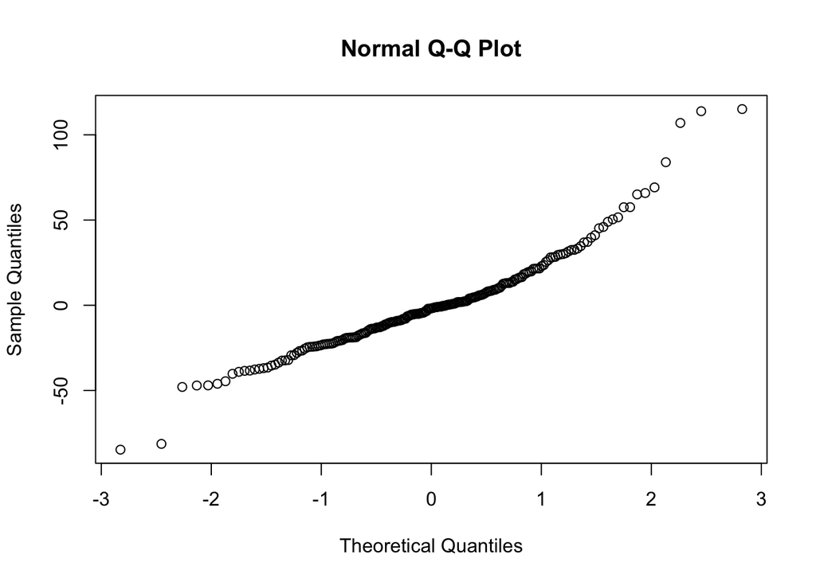

```r
qqnorm(residuals(model5))
```